# Gender Pay Gap: Individuatl Dataset

DS1 Final Project 09.07.2020 Maki Terao Part C: individual data set

```r
library(tidyverse)
library(ggplot2)
library(corrplot)
library (readr)
library(plyr)
library(reldist)#for gini coefficients
```

Data is 2018 ACS PUMS Massachusetts State (This is for MA analysis, Script is same for WA and GA) https://www2.census.gov/programs-surveys/acs/data/pums/2018/1-Year/

```r
setwd("C:/Users/terao/OneDrive/DataScience/BLS")
data=read_csv("psam_p25.csv", col_names=T)
#chose related variables. including child variable (I can only find OC and PAOC in this dataset)
ma=data[c("AGEP","HISP","NATIVITY","MAR","SEX","SCHL","SCHG","RELP","RAC1P","OCCP","WAOB", "OC","PAOC", "WAGP")]
```

View missing values

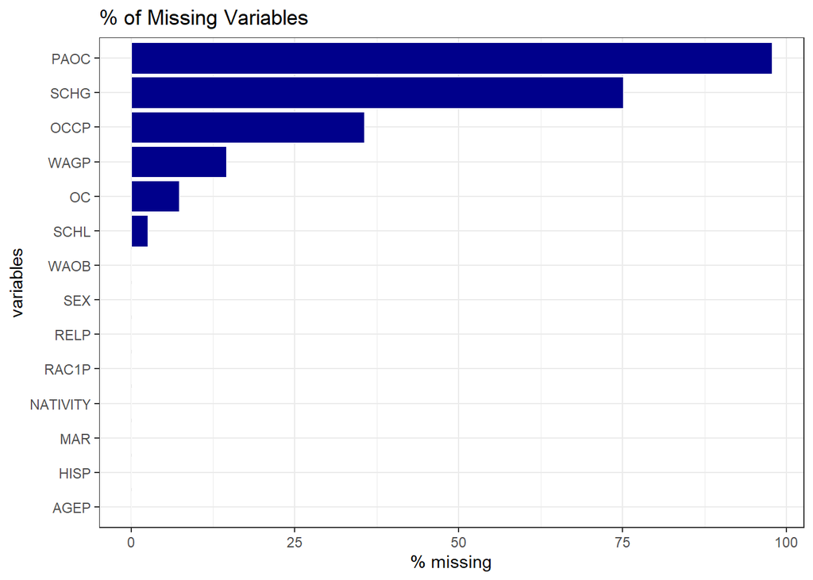

```r
missing_data = ma%>% summarise_all(funs(sum(is.na(.))/n()))
missing_data = gather(missing_data, key = "variables", value = "percent_missing")
ggplot(missing_data, aes(x = reorder(variables, percent_missing), y = percent_missing*100)) +
  geom_bar(stat = "identity", fill = "dark blue", aes(color = I('white')), size = 0.3)+
  xlab('variables')+ylab('% missing')+ggtitle('% of Missing Variables')+
  coord_flip()+
  theme_bw()
```

Take a look SEX, 1 male, 2 female, OC “child” , PAOC, “cild and their age” distribution of entire dataset. PAOC does not provide much information.

```r
ma$SEX=factor(ma$SEX)
table(ma$SEX)
```

```
##
##     1     2
## 33880 36251
```

```r
ma$OC=factor(ma$OC)
table(ma$OC)
```

```
##
## FALSE  TRUE
## 53702 11300
```

```r
ma$PAOC=factor(ma$PAOC)
table(ma$PAOC)
```

```
##
## TRUE
## 1558
```

Drop all observations with $0 WAGP (last 12 months wage) variable and take a look child, education and age variables for the group.

```r
maworker=subset(ma, WAGP!=0)
summary(maworker$WAGP)
```

```
##    Min. 1st Qu.  Median    Mean 3rd Qu.    Max.
##       4   18000   45000   63169   80000  620000
```

```r
table(maworker$OC)
```

```
##
## FALSE  TRUE
## 35119   648
```

```r
summary(maworker$AGEP)
```

```
##    Min. 1st Qu.  Median    Mean 3rd Qu.    Max.
##   16.00   29.00   42.00   42.41   55.00   95.00
```

Create “ocpCat” occupation category (530 subcategories to 25 major cotegories)

```r
maworker$OCCP=as.numeric(maworker$OCCP)

x=maworker$OCCP
maworker$ocpCat[x<=440]="MGR"
maworker$ocpCat[500<=x & x<=750]="BUS"
maworker$ocpCat[800<=x & x <= 960]="FIN"
maworker$ocpCat[1005<=x & x<=1240]="CMM"
maworker$ocpCat[1305<=x & x <= 1560]="ENG"
maworker$ocpCat[1600<=x & x<=1980]="SCI"
maworker$ocpCat[2001<=x & x <= 2060]="CMS"
maworker$ocpCat[2100<=x & x<=2180]="LGL"
maworker$ocpCat[2205<=x & x <= 2555]="EDU"
maworker$ocpCat[2600<=x & x<=2920]="ENT"
maworker$ocpCat[3000<=x & x <= 3550]="MED"
maworker$ocpCat[3601<=x & x <= 3655]="HLS"
maworker$ocpCat[3700<=x & x<=3960]="PRT"
maworker$ocpCat[4000<=x & x <= 4160]="EAT"
maworker$ocpCat[4200<=x & x<=4255]="CLN"
maworker$ocpCat[4330<=x & x <= 4655]="PRS"
maworker$ocpCat[4700<=x & x <= 4965]="SAL"
maworker$ocpCat[5000<=x & x<=5940]="OFF"
maworker$ocpCat[6005<=x & x <= 6130]="FFF"
maworker$ocpCat[6200<=x & x<=6765]="CON"
maworker$ocpCat[6800<=x & x <= 6950]="EXT"
maworker$ocpCat[7000<=x & x <= 7750]="RPR"
maworker$ocpCat[7800<=x & x<=8990]="PRD"
maworker$ocpCat[9005<=x & x <= 9760]="TRN"
maworker$ocpCat[9800<=x & x<=9830]="MIL"
maworker$ocpCat[9920==x]="UNE"
```

Drop annual wage value less than $23,920 (38,237->26,655) Exclude part-time, less than full year workers. Median increases $65,000

```r
maworkerF=subset(maworker, WAGP >= 23920)
summary(maworkerF$WAGP)
```

```
##    Min. 1st Qu.  Median    Mean 3rd Qu.    Max.
##   24000   40100   65000   86516  100000  620000
```

Take a look at SEX and OC after dropping less than 23,900 and median wage by sex.

```r
table(maworkerF$OC) #only 1 observation with child (unable to use this variable)
```

```
##
## FALSE  TRUE
## 26408     1
```

```r
table(maworkerF$MAR)#1 Married~5 Never Married (see EDA below for description)
```

```
##
##     1     2     3     4     5
## 15937   392  2581   357  7388
```

```r
#by sex male , female
mwsex=ddply(maworkerF, .(SEX), summarize, medwage=median(WAGP))
mwsex
```

```
##   SEX medwage
## 1   1   70000
## 2   2   57000
```

Calculate male/ female median wage, pay gap, and number of workers by ocpCat

```r
mwlist=ddply(maworkerF, .(ocpCat), summarize, medwage=median(WAGP))
#median wage by ocpCat
d=aggregate(maworkerF$WAGP, by=list(maworkerF$ocpCat,maworkerF$SEX), FUN=median)
colnames(d)=c("ocpCat", "SEX", "wage")
d=spread(d,SEX, wage)
mwlist=left_join(mwlist, d, by="ocpCat", dupliate=F)
names(mwlist)[3]="male"
names(mwlist)[4]="female"
mwlist$mapper=mwlist$female/mwlist$male
#num of workers by ocpCat
mwlist$ttlwk=table(maworkerF$ocpCat)
e=maworkerF %>% group_by(SEX, ocpCat) %>% tally()
e=spread(e,SEX,n)
mwlist=left_join(mwlist, e, by="ocpCat", duplicate=F)
names(mwlist)[7]="ttlml"
names(mwlist)[8]="ttlfl"

#write.csv(mwlist,"ocpCatma.csv", row.names=F)
```

Create age category “ageC”

```r
summary(maworkerF$AGEP) #median 46, Mean 45.13 (higher than WA & GA)
```

```
##    Min. 1st Qu.  Median    Mean 3rd Qu.    Max.
##   17.00   33.00   46.00   45.13   56.00   95.00
```

```r
x=maworkerF$AGEP
maworkerF$ageC[x<=24]="1"
maworkerF$ageC[25<=x & x<=34]="2"
maworkerF$ageC[35<=x & x <= 44]="3"
maworkerF$ageC[45<=x & x<=54]="4"
maworkerF$ageC[55<=x & x <= 64]="5"
maworkerF$ageC[65<=x]="6"
table(maworkerF$ageC)
```

```
##
##    1    2    3    4    5    6
## 1252 6083 5444 6157 5883 1836
```

Create race category “raceC” and “latino” I will assume “HISP” variable’s 02~24 are latino and within non-latino group, categorize by variable RAC1P. RAC1P, I will categorize by 1.White, 2. Black 6. Asian, 3~5&7. Native, 8& 9.other

```r
#table(maworkerF$RAC1P) #no hispanic category
#table(maworkerF$HISP)  #01: not hispanic 02~24: hispanic

x=maworkerF$HISP
maworkerF$latino[x=="01"]="0" #not-hispanic/ latino
maworkerF$latino[x!="01"]="1" #hispanic
#table(maworkerF$latino)# 0=24,928, 1=1727

x=maworkerF$RAC1P
y=maworkerF$latino
maworkerF$raceC[y!=1 & x==1]="1" #white
maworkerF$raceC[y!=1 & x==2]="2" #black
maworkerF$raceC[y!=1 & x==6 ]="3" #asian
maworkerF$raceC[y!=1 & (x==3|x==4|x==5|x==7)]="5"#native
maworkerF$raceC[y!=1 & (x==8|x==9)]="6"#other
maworkerF$raceC[y==1]="4"#hispanic or latino
table(maworkerF$raceC)
```

```
##
##     1     2     3     4     5     6
## 21333  1246  1778  1727    34   537
```

Create education attainment category “edC” see EDA for category description.

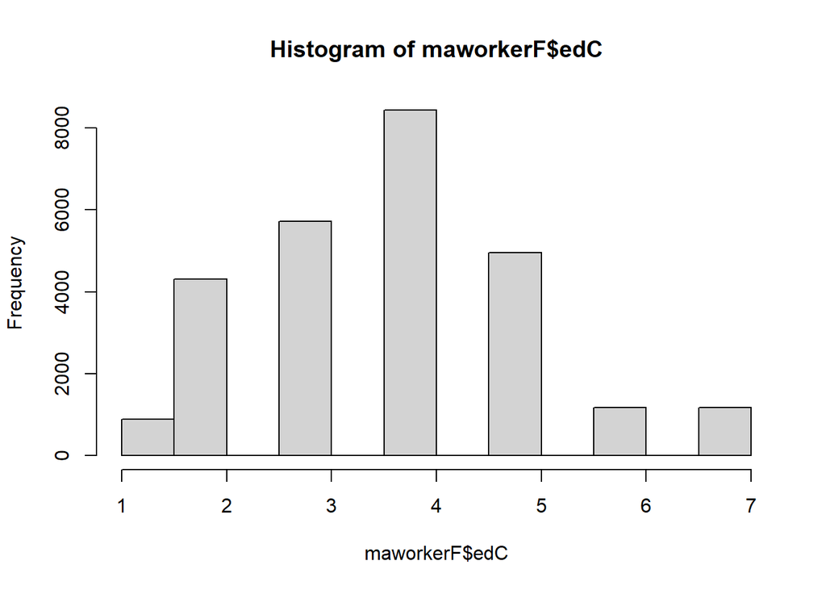

```r
x=maworkerF$SCHL
maworkerF$edC[x<=15]="1"
maworkerF$edC[16<=x & x<=17]="2"
maworkerF$edC[18<=x & x <= 20]="3"
maworkerF$edC[x==21]="4"
maworkerF$edC[x==22]="5"
maworkerF$edC[x==23]="6"
maworkerF$edC[x==24]="7"
maworkerF$edC=as.numeric(maworkerF$edC)
hist(maworkerF$edC)
```

Take a look at variance, etc.

```r
var(log(maworkerF$WAGP))
```

```
## [1] 0.4157282
```

```r
sd(maworkerF$WAGP)
```

```
## [1] 84911.93
```

```r
gini(maworkerF$WAGP)
```

```
## [1] 0.3911723
```

```r
#write.csv(maworkerF,"maworkerF.csv",row.names=F)
#maworkerF=read.csv("maworkerF.csv")
```

EDA Total population by SEX: (remove package “plyr”)

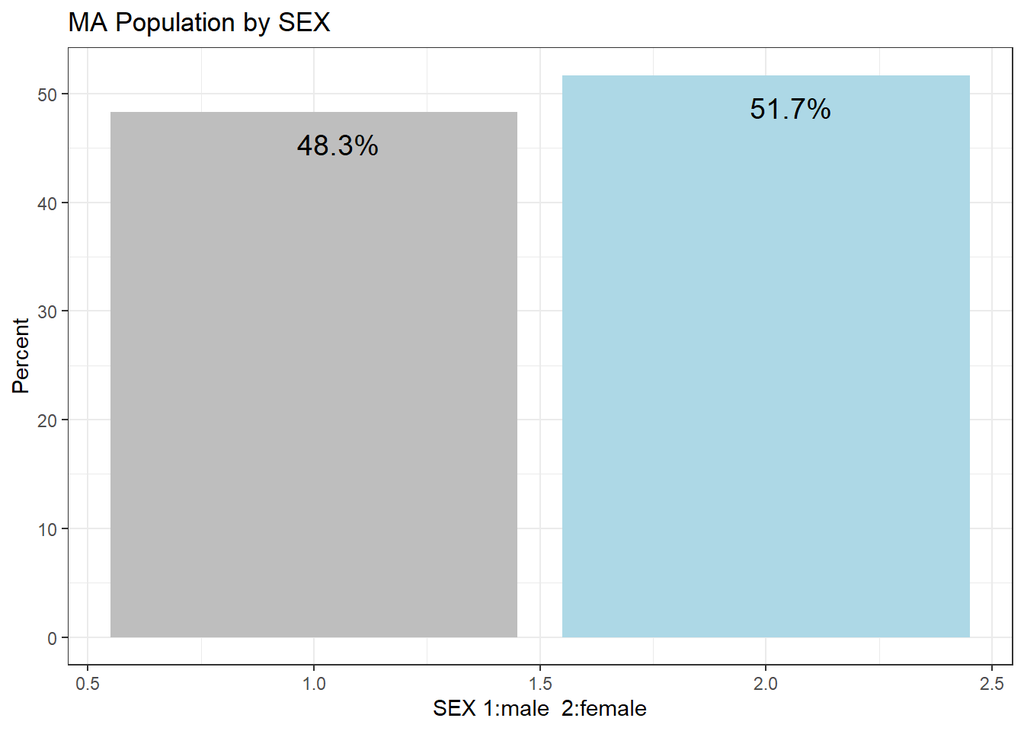

```r
detach("package:plyr", unload = TRUE)

par(mfrow=c(1,4))
#all dataset
data %>%
  group_by(SEX) %>%
  summarise(Count = n())%>%
  mutate(percent = prop.table(Count)*100)%>%
  ggplot(aes(x=SEX,y=percent), fill = SEX)+
  geom_col(fill = c("grey", "light blue"))+
  geom_text(aes(label = sprintf("%.1f%%", percent)), hjust = 0.2, vjust = 2, size = 5)+
  theme_bw()+
  xlab("SEX 1:male  2:female") + ylab("Percent") + ggtitle("MA Population by SEX")
```

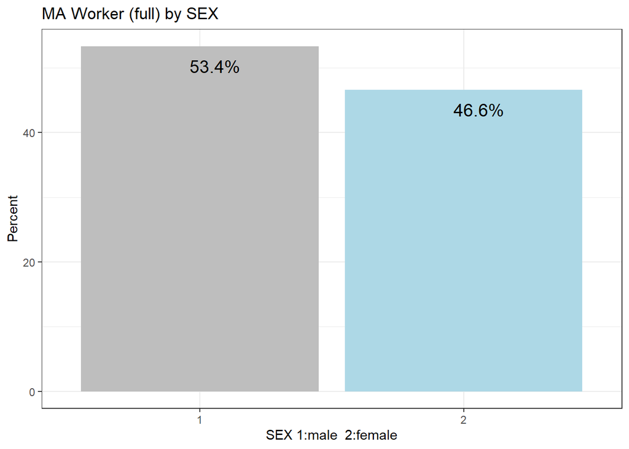

```r
#workers only
maworkerF %>%
  group_by(SEX) %>%
  summarise(Count = n())%>%
  mutate(percent = prop.table(Count)*100)%>%
  ggplot(aes(x=SEX, y=percent), fill = SEX)+
  geom_col(fill = c("grey", "light blue"))+
  geom_text(aes(label = sprintf("%.1f%%", percent)), hjust = 0.2, vjust = 2, size = 5)+
  theme_bw()+
  xlab("SEX 1:male  2:female") + ylab("Percent") + ggtitle("MA Worker (full) by SEX")
```

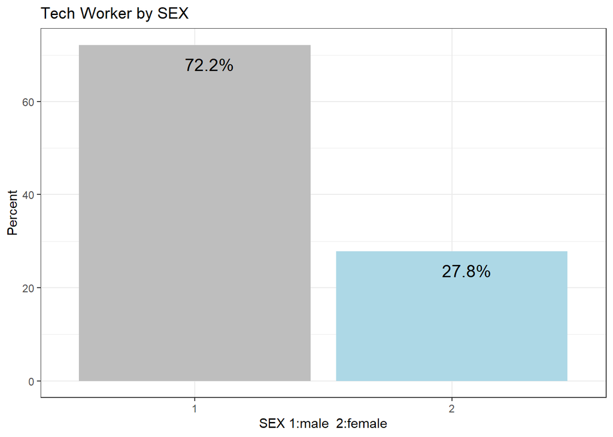

```r
#tech (CMM) only subset
maCMM=subset(maworkerF, ocpCat=="CMM") #1562 ttl
maCMM %>%
  group_by(SEX) %>%
  summarise(Count = n())%>%
  mutate(percent = prop.table(Count)*100)%>%
  ggplot(aes(x=SEX, y=percent), fill = SEX)+
  geom_col(fill = c("grey", "light blue"))+
  geom_text(aes(label = sprintf("%.1f%%", percent)), hjust = 0.2, vjust = 2, size = 5)+ theme_bw()+
  xlab("SEX 1:male  2:female") + ylab("Percent") + ggtitle("Tech Worker by SEX")
```

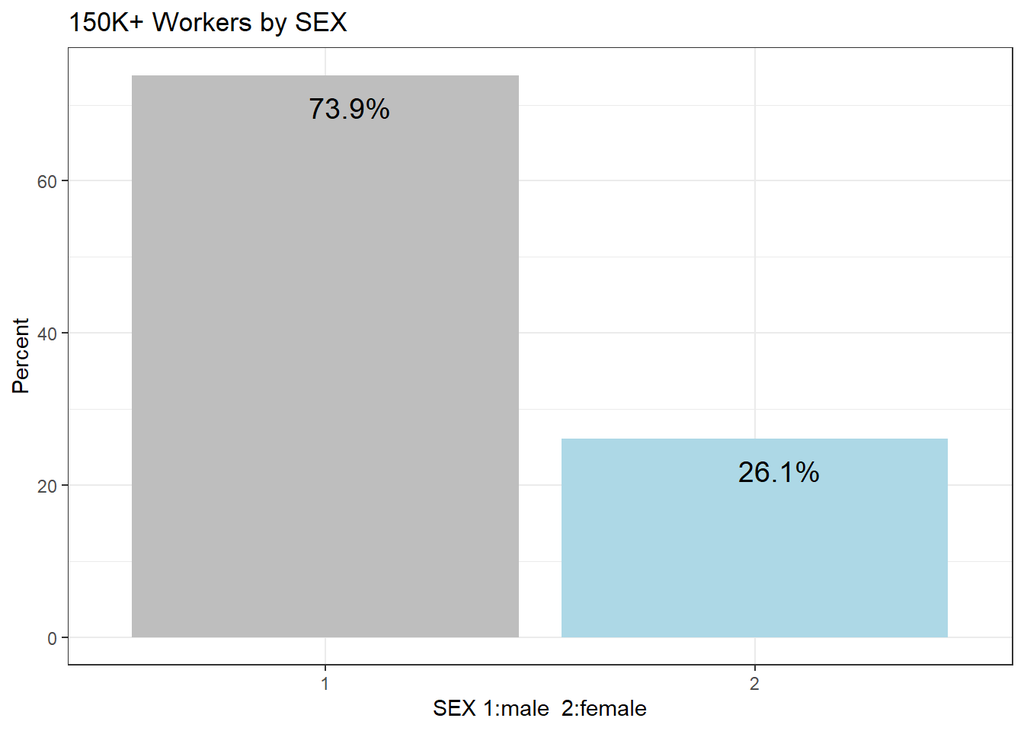

```r
#high wage only
maHW=subset(maworkerF, WAGP>=150000)
maHW %>%
  group_by(SEX) %>%
  summarise(Count = n())%>%
  mutate(percent = prop.table(Count)*100)%>%
  ggplot(aes(x=SEX, y=percent), fill = SEX)+
  geom_col(fill = c("grey", "light blue"))+
  geom_text(aes(label = sprintf("%.1f%%", percent)), hjust = 0.2, vjust = 2, size = 5)+ theme_bw()+
  xlab("SEX 1:male  2:female") + ylab("Percent") + ggtitle("150K+ Workers by SEX")
```

Median Wage by SEX

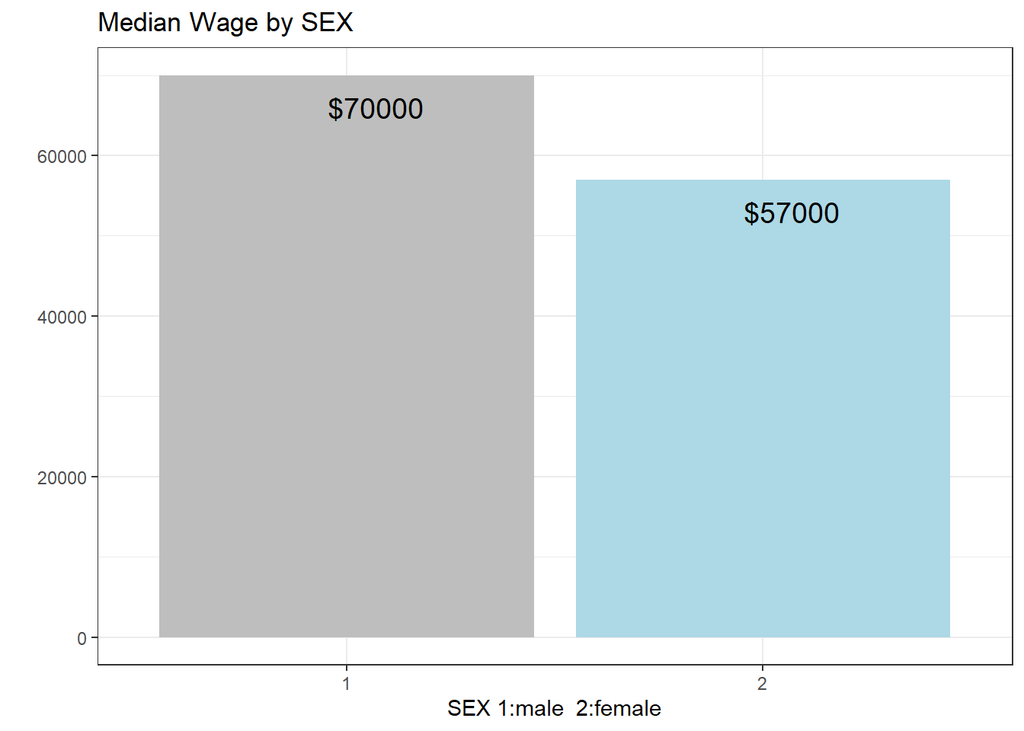

```r
mwsex %>% ggplot(aes(x=SEX, y=medwage))+geom_col(fill=c('grey','light blue'))+
  geom_text(aes(label=paste0("$", medwage)), hjust = 0.2, vjust = 2, size = 5)+
   theme_bw()+
  xlab("SEX 1:male  2:female") + ylab("") + ggtitle("Median Wage by SEX")
```

Number of workers & median wage by occupational category

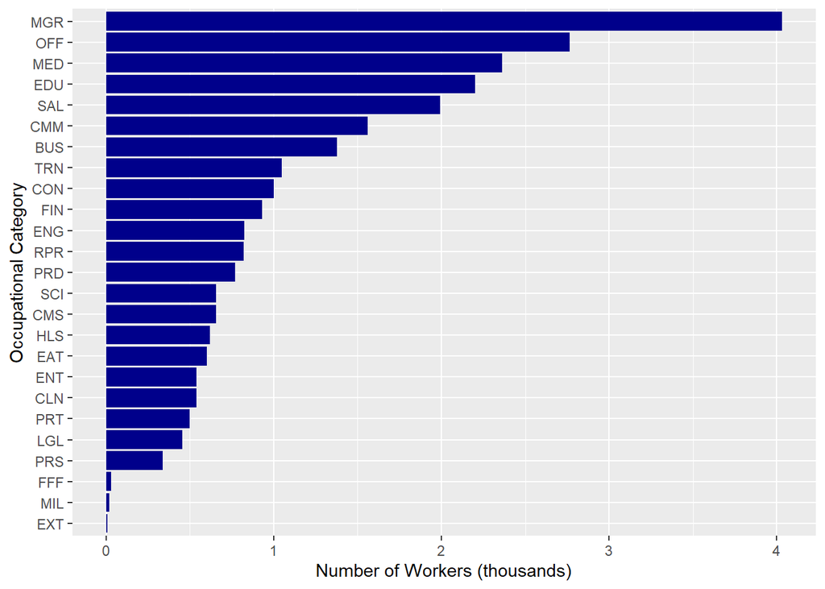

```r
par(mfrow=c(1,2))
#num of workders by Occupational Category
maworkerF %>% group_by(ocpCat) %>% summarise(ocp=n()/1000)  %>%
  ggplot(aes(x=reorder(ocpCat, ocp),y=ocp))+geom_bar(stat='identity', fill='dark blue')+
  coord_flip()+
  labs(x='Occupational Category', y='Number of Workers (thousands)')
```

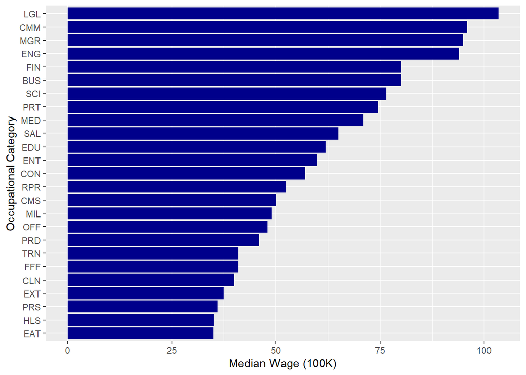

```r
#median wage by occp category
mwlist %>% ggplot(aes(x=reorder(ocpCat, medwage), y=medwage/1000))+
  geom_bar(stat='identity', fill='dark blue')+coord_flip()+
  labs(x='Occupational Category', y='Median Wage (100K)')
```

Number of workers by education attainment

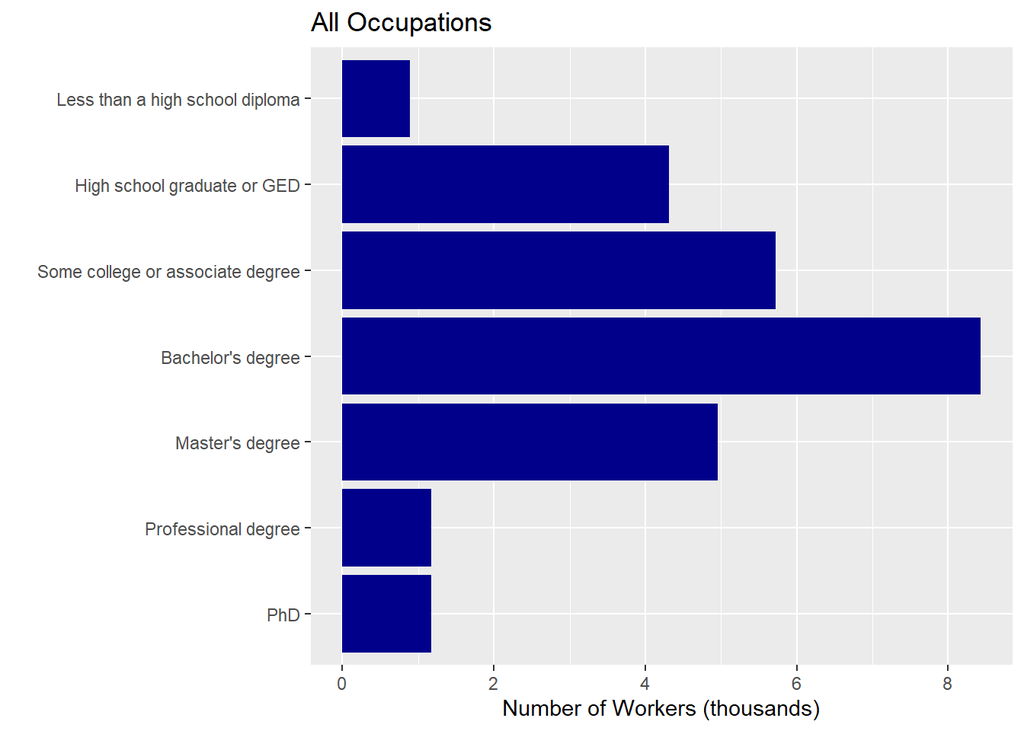

```r
par(mfrow=c(1,2))
ed_class=c('1'='Less than a high school diploma', '2'='High school graduate or GED', '3'='Some college or associate degree',
           '4'="Bachelor's degree", '5'="Master's degree", '6'="Professional degree", '7'="PhD")
#all workers
maworkerF %>% group_by(edC) %>% summarize(n=n()) %>%
  ggplot(aes(x=reorder(ed_class[edC], -edC), y=n/1000))+geom_bar(stat='identity', fill='dark blue')+
  labs(x='', y='Number of Workers (thousands)', title='All Occupations' )+
  coord_flip()
```

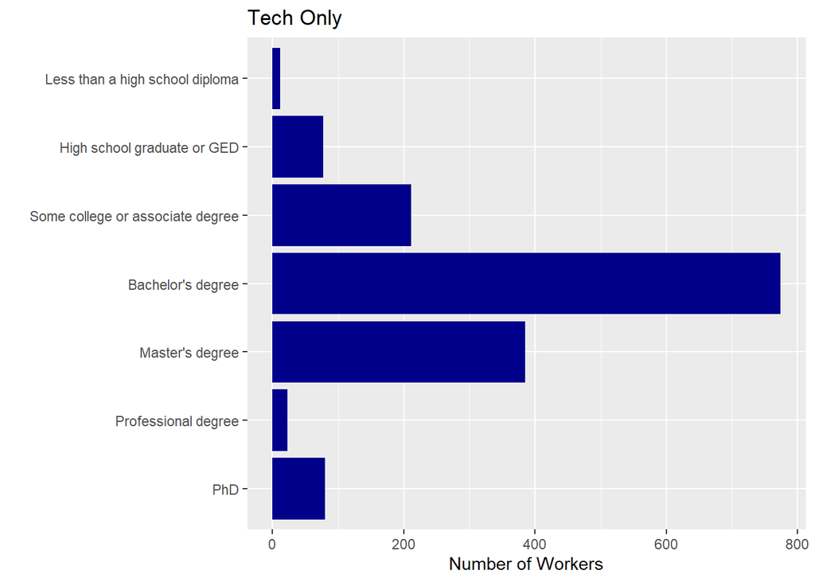

```r
#tech only
maCMM %>% group_by(edC) %>% summarize(n=n()) %>%
  ggplot(aes(x=reorder(ed_class[edC], -edC), y=n))+geom_bar(stat='identity', fill='dark blue')+
  labs(x='', y='Number of Workers', title='Tech Only' )+
  coord_flip()
```

Number of workers by age group

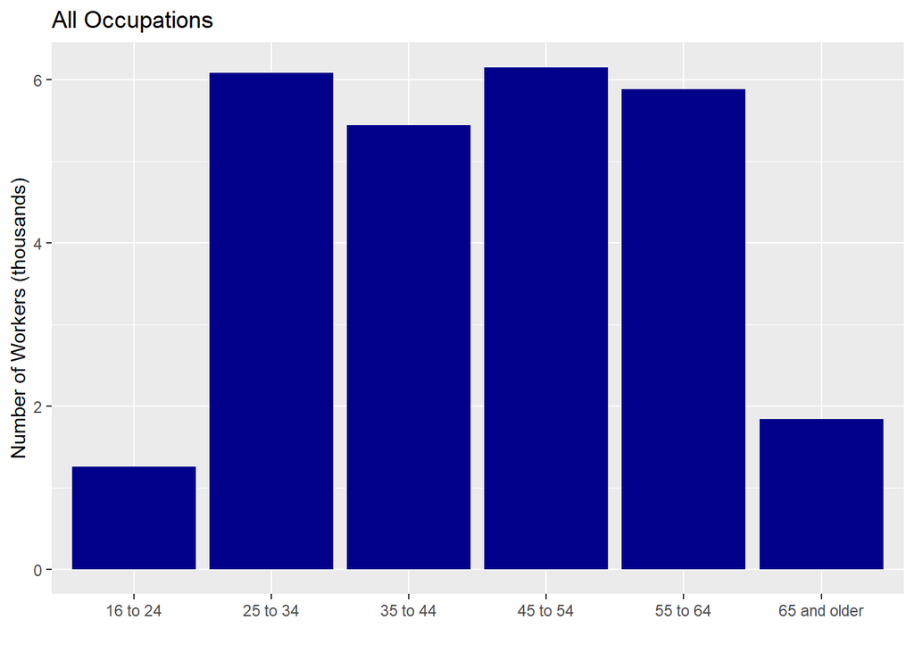

```r
age_class=c('1'='16 to 24', '2'='25 to 34', '3'='35 to 44', '4'='45 to 54', '5'='55 to 64', '6'='65 and older')
maworkerF %>% group_by(ageC) %>% summarize(n=n()) %>%
  ggplot(aes(x=age_class[ageC], y=n/1000))+geom_bar(stat='identity', fill='dark blue')+
  labs(x='', y='Number of Workers (thousands)', title='All Occupations' )
```

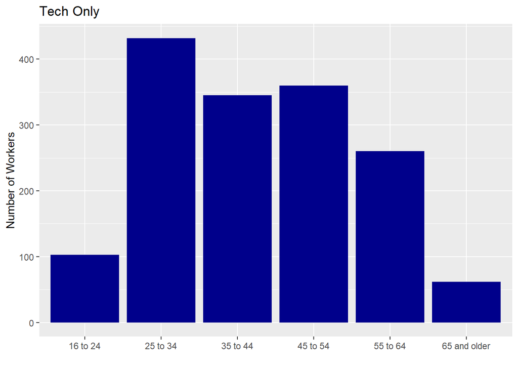

```r
maCMM %>% group_by(ageC) %>% summarize(n=n()) %>%
  ggplot(aes(x=age_class[ageC], y=n))+geom_bar(stat='identity', fill='dark blue')+
  labs(x='', y='Number of Workers', title='Tech Only' )
```

Change ageC, SEX, raceC(latino), MAR, Nativity variables to factor

```r
mdata=maworkerF[c('ageC','SEX','edC','raceC','MAR','NATIVITY','ocpCat','OCCP','WAGP')]
mdata[,c(1:8)]=lapply(mdata[c(1:8)], as.factor)
#all with WAGP
fit1=lm(WAGP~.-OCCP, data=mdata)
summary(fit1)
```

```
##
## Call:
## lm(formula = WAGP ~ . - OCCP, data = mdata)
##
## Residuals:
##     Min      1Q  Median      3Q     Max
## -191357  -32262   -8240   14960  608952
##
## Coefficients:
##             Estimate Std. Error t value Pr(>|t|)
## (Intercept)  70092.6     4202.4  16.679  < 2e-16 ***
## ageC2         1452.0     2351.9   0.617  0.53699
## ageC3        20688.0     2506.8   8.253  < 2e-16 ***
## ageC4        31025.6     2515.4  12.334  < 2e-16 ***
## ageC5        27062.5     2544.4  10.636  < 2e-16 ***
## ageC6        16182.9     2952.2   5.482 4.25e-08 ***
## SEX2        -28018.1     1023.7 -27.370  < 2e-16 ***
## edC2         -1088.8     2781.8  -0.391  0.69550
## edC3          4279.1     2781.4   1.538  0.12395
## edC4         30288.5     2829.6  10.704  < 2e-16 ***
## edC5         46952.4     2954.4  15.893  < 2e-16 ***
## edC6        102021.4     3657.3  27.896  < 2e-16 ***
## edC7         65144.3     3584.1  18.176  < 2e-16 ***
## raceC2       -8281.4     2273.4  -3.643  0.00027 ***
## raceC3        1153.7     2113.9   0.546  0.58522
## raceC4       -3959.4     1982.8  -1.997  0.04585 *
## raceC5       -3682.0    12688.5  -0.290  0.77168
## raceC6       -5232.3     3262.5  -1.604  0.10878
## MAR2         -9321.8     3840.0  -2.428  0.01521 *
## MAR3        -10663.6     1595.9  -6.682 2.41e-11 ***
## MAR4        -12533.2     3979.6  -3.149  0.00164 **
## MAR5        -17064.2     1228.6 -13.889  < 2e-16 ***
## NATIVITY2    -2664.8     1465.6  -1.818  0.06904 .
## ocpCatCLN   -31943.5     3893.5  -8.204 2.42e-16 ***
## ocpCatCMM     2049.3     2756.6   0.743  0.45724
## ocpCatCMS   -39210.8     3525.9 -11.121  < 2e-16 ***
## ocpCatCON   -21963.2     3250.7  -6.756 1.44e-11 ***
## ocpCatEAT   -23915.8     3705.1  -6.455 1.10e-10 ***
## ocpCatEDU   -38157.9     2583.0 -14.773  < 2e-16 ***
## ocpCatENG    -3367.7     3280.0  -1.027  0.30455
```

[output cut: 8 more lines]

```
## ocpCatMIL   -53364.7    17544.7  -3.042  0.00236 **
## ocpCatOFF   -18677.3     2500.9  -7.468 8.38e-14 ***
## ocpCatPRD   -27866.1     3455.6  -8.064 7.69e-16 ***
## ocpCatPRS   -24495.6     4520.8  -5.418 6.07e-08 ***
## ocpCatPRT   -15455.7     3909.4  -3.953 7.72e-05 ***
## ocpCatRPR   -24252.8     3382.8  -7.169 7.73e-13 ***
## ocpCatSAL     4647.6     2619.9   1.774  0.07608 .
## ocpCatSCI   -17806.7     3622.5  -4.916 8.91e-07 ***
## ocpCatTRN   -30025.4     3168.9  -9.475  < 2e-16 ***
## ---
## Signif. codes:  0 '***' 0.001 '**' 0.01 '*' 0.05 '.' 0.1 ' ' 1
##
## Residual standard error: 73890 on 26608 degrees of freedom
## Multiple R-squared:  0.2442, Adjusted R-squared:  0.2429
## F-statistic: 186.9 on 46 and 26608 DF,  p-value: < 2.2e-16
```

All workers with log WAGP (better R^2)

```r
fit2=lm(log(WAGP)~.-OCCP, data=mdata)
summary(fit2)
```

```
##
## Call:
## lm(formula = log(WAGP) ~ . - OCCP, data = mdata)
##
## Residuals:
##      Min       1Q   Median       3Q      Max
## -1.99946 -0.31285 -0.00616  0.28138  3.10138
##
## Coefficients:
##              Estimate Std. Error t value Pr(>|t|)
## (Intercept) 10.836517   0.028509 380.102  < 2e-16 ***
## ageC2        0.172224   0.015955  10.794  < 2e-16 ***
## ageC3        0.360472   0.017006  21.196  < 2e-16 ***
## ageC4        0.429238   0.017064  25.154  < 2e-16 ***
## ageC5        0.402999   0.017262  23.347  < 2e-16 ***
## ageC6        0.269025   0.020028  13.432  < 2e-16 ***
## SEX2        -0.230076   0.006945 -33.130  < 2e-16 ***
## edC2         0.020012   0.018872   1.060 0.288985
## edC3         0.089942   0.018870   4.767 1.88e-06 ***
## edC4         0.340815   0.019196  17.754  < 2e-16 ***
## edC5         0.490014   0.020043  24.449  < 2e-16 ***
## edC6         0.784153   0.024811  31.605  < 2e-16 ***
## edC7         0.642060   0.024315  26.406  < 2e-16 ***
## raceC2      -0.096839   0.015423  -6.279 3.46e-10 ***
## raceC3       0.006539   0.014341   0.456 0.648420
## raceC4      -0.077059   0.013451  -5.729 1.02e-08 ***
## raceC5      -0.029600   0.086080  -0.344 0.730951
## raceC6      -0.050669   0.022133  -2.289 0.022071 *
## MAR2        -0.084778   0.026051  -3.254 0.001138 **
## MAR3        -0.079411   0.010827  -7.335 2.29e-13 ***
## MAR4        -0.097997   0.026998  -3.630 0.000284 ***
## MAR5        -0.167624   0.008335 -20.111  < 2e-16 ***
## NATIVITY2   -0.048748   0.009943  -4.903 9.50e-07 ***
## ocpCatCLN   -0.446505   0.026414 -16.904  < 2e-16 ***
## ocpCatCMM    0.094964   0.018701   5.078 3.84e-07 ***
## ocpCatCMS   -0.433781   0.023920 -18.135  < 2e-16 ***
## ocpCatCON   -0.210335   0.022053  -9.538  < 2e-16 ***
## ocpCatEAT   -0.453071   0.025136 -18.025  < 2e-16 ***
## ocpCatEDU   -0.383920   0.017523 -21.909  < 2e-16 ***
## ocpCatENG    0.030154   0.022252   1.355 0.175386
```

[output cut: 8 more lines]

```
## ocpCatMIL   -0.488400   0.119025  -4.103 4.08e-05 ***
## ocpCatOFF   -0.279733   0.016966 -16.488  < 2e-16 ***
## ocpCatPRD   -0.338887   0.023443 -14.456  < 2e-16 ***
## ocpCatPRS   -0.441027   0.030670 -14.380  < 2e-16 ***
## ocpCatPRT   -0.102649   0.026522  -3.870 0.000109 ***
## ocpCatRPR   -0.250110   0.022949 -10.898  < 2e-16 ***
## ocpCatSAL   -0.055954   0.017774  -3.148 0.001645 **
## ocpCatSCI   -0.163637   0.024576  -6.659 2.82e-11 ***
## ocpCatTRN   -0.394979   0.021498 -18.373  < 2e-16 ***
## ---
## Signif. codes:  0 '***' 0.001 '**' 0.01 '*' 0.05 '.' 0.1 ' ' 1
##
## Residual standard error: 0.5012 on 26608 degrees of freedom
## Multiple R-squared:  0.3967, Adjusted R-squared:  0.3956
## F-statistic: 380.3 on 46 and 26608 DF,  p-value: < 2.2e-16
```

All workers all 530 OCCP facotrs & log WAGP +OCCP (MAR and NATIVITY did not show so I changed variables order)

```r
fit3=lm(log(WAGP)~.-ocpCat, data=mdata)#adj R2=0.4488 SEX2=-0.1914
summary(fit3)
```

```
##
## Call:
## lm(formula = log(WAGP) ~ . - ocpCat, data = mdata)
##
## Residuals:
##      Min       1Q   Median       3Q      Max
## -2.07190 -0.28911 -0.00923  0.26097  3.08452
##
## Coefficients:
##              Estimate Std. Error t value Pr(>|t|)
## (Intercept) 11.428998   0.034816 328.272  < 2e-16 ***
## ageC2        0.173035   0.015512  11.155  < 2e-16 ***
## ageC3        0.360564   0.016543  21.796  < 2e-16 ***
## ageC4        0.426670   0.016615  25.680  < 2e-16 ***
## ageC5        0.402824   0.016797  23.982  < 2e-16 ***
## ageC6        0.282966   0.019480  14.526  < 2e-16 ***
## SEX2        -0.191409   0.007069 -27.077  < 2e-16 ***
## edC2         0.009156   0.018394   0.498 0.618674
## edC3         0.055879   0.018468   3.026 0.002483 **
## edC4         0.250511   0.018908  13.249  < 2e-16 ***
## edC5         0.379750   0.019871  19.110  < 2e-16 ***
## edC6         0.501165   0.026911  18.623  < 2e-16 ***
## edC7         0.495609   0.024851  19.943  < 2e-16 ***
## raceC2      -0.071532   0.015085  -4.742 2.13e-06 ***
## raceC3       0.001537   0.013956   0.110 0.912303
## raceC4      -0.054441   0.013099  -4.156 3.25e-05 ***
## raceC5      -0.036063   0.083031  -0.434 0.664049
## raceC6      -0.037319   0.021496  -1.736 0.082563 .
## MAR2        -0.064523   0.025105  -2.570 0.010172 *
## MAR3        -0.065964   0.010438  -6.319 2.67e-10 ***
## MAR4        -0.073658   0.026057  -2.827 0.004705 **
## MAR5        -0.148112   0.008075 -18.342  < 2e-16 ***
## NATIVITY2   -0.046104   0.009661  -4.772 1.83e-06 ***
## OCCP20      -0.434123   0.039596 -10.964  < 2e-16 ***
## OCCP40      -0.431227   0.153501  -2.809 0.004969 **
## OCCP51      -0.405839   0.043665  -9.294  < 2e-16 ***
## OCCP52      -0.214050   0.050412  -4.246 2.18e-05 ***
## OCCP60      -0.476251   0.097258  -4.897 9.80e-07 ***
## OCCP101     -0.547674   0.122280  -4.479 7.54e-06 ***
## OCCP102     -0.661872   0.080632  -8.209 2.34e-16 ***
```

[output cut: 484 more lines]

```
## OCCP9630    -0.956780   0.215850  -4.433 9.35e-06 ***
## OCCP9640    -1.018184   0.082867 -12.287  < 2e-16 ***
## OCCP9645    -1.089944   0.050113 -21.750  < 2e-16 ***
## OCCP9720    -1.078925   0.147267  -7.326 2.43e-13 ***
## OCCP9760    -0.839416   0.182828  -4.591 4.43e-06 ***
## OCCP9800    -1.030836   0.479401  -2.150 0.031544 *
## OCCP9810    -0.619392   0.277654  -2.231 0.025703 *
## OCCP9825    -1.019767   0.240804  -4.235 2.29e-05 ***
## OCCP9830    -1.085765   0.153509  -7.073 1.55e-12 ***
## ---
## Signif. codes:  0 '***' 0.001 '**' 0.01 '*' 0.05 '.' 0.1 ' ' 1
##
## Residual standard error: 0.4787 on 26132 degrees of freedom
## Multiple R-squared:  0.4596, Adjusted R-squared:  0.4488
## F-statistic: 42.58 on 522 and 26132 DF,  p-value: < 2.2e-16
```

Exclude high wage group n=23,996 (90.02% of total maworkerF) R2 0.3435 SEX2=-0.1315

```r
mdataP=subset(mdata, WAGP <=150000)
fit5=lm(log(WAGP)~.-OCCP, data=mdataP)
summary(fit5)
```

```
##
## Call:
## lm(formula = log(WAGP) ~ . - OCCP, data = mdataP)
##
## Residuals:
##      Min       1Q   Median       3Q      Max
## -1.54784 -0.26500  0.02054  0.27775  1.43583
##
## Coefficients:
##              Estimate Std. Error t value Pr(>|t|)
## (Intercept) 10.741271   0.022873 469.605  < 2e-16 ***
## ageC2        0.209781   0.012556  16.708  < 2e-16 ***
## ageC3        0.335263   0.013493  24.847  < 2e-16 ***
## ageC4        0.369869   0.013551  27.295  < 2e-16 ***
## ageC5        0.353867   0.013729  25.774  < 2e-16 ***
## ageC6        0.228707   0.016089  14.216  < 2e-16 ***
## SEX2        -0.131556   0.005762 -22.833  < 2e-16 ***
## edC2         0.040530   0.014938   2.713  0.00667 **
## edC3         0.099250   0.014956   6.636 3.29e-11 ***
## edC4         0.264212   0.015288  17.282  < 2e-16 ***
## edC5         0.373162   0.016109  23.164  < 2e-16 ***
## edC6         0.394314   0.021654  18.210  < 2e-16 ***
## edC7         0.444853   0.020358  21.852  < 2e-16 ***
## raceC2      -0.071502   0.012314  -5.806 6.46e-09 ***
## raceC3       0.002507   0.012092   0.207  0.83577
## raceC4      -0.074501   0.010823  -6.884 5.98e-12 ***
## raceC5      -0.015494   0.068319  -0.227  0.82058
## raceC6      -0.035021   0.017821  -1.965  0.04940 *
## MAR2        -0.050127   0.020979  -2.389  0.01688 *
## MAR3        -0.041975   0.008799  -4.770 1.85e-06 ***
## MAR4        -0.068576   0.021849  -3.139  0.00170 **
## MAR5        -0.123908   0.006721 -18.437  < 2e-16 ***
## NATIVITY2   -0.054712   0.008244  -6.637 3.28e-11 ***
## ocpCatCLN   -0.383347   0.021104 -18.165  < 2e-16 ***
## ocpCatCMM    0.149353   0.015652   9.542  < 2e-16 ***
## ocpCatCMS   -0.332793   0.019227 -17.308  < 2e-16 ***
## ocpCatCON   -0.136001   0.017813  -7.635 2.34e-14 ***
## ocpCatEAT   -0.433273   0.020129 -21.525  < 2e-16 ***
## ocpCatEDU   -0.268870   0.014401 -18.670  < 2e-16 ***
## ocpCatENG    0.093230   0.018597   5.013 5.39e-07 ***
```

[output cut: 8 more lines]

```
## ocpCatMIL   -0.305190   0.093161  -3.276  0.00105 **
## ocpCatOFF   -0.255373   0.013916 -18.350  < 2e-16 ***
## ocpCatPRD   -0.275791   0.018855 -14.627  < 2e-16 ***
## ocpCatPRS   -0.420790   0.024360 -17.274  < 2e-16 ***
## ocpCatPRT   -0.026016   0.021525  -1.209  0.22682
## ocpCatRPR   -0.171952   0.018485  -9.302  < 2e-16 ***
## ocpCatSAL   -0.125600   0.014915  -8.421  < 2e-16 ***
## ocpCatSCI   -0.102863   0.020489  -5.020 5.19e-07 ***
## ocpCatTRN   -0.334241   0.017382 -19.229  < 2e-16 ***
## ---
## Signif. codes:  0 '***' 0.001 '**' 0.01 '*' 0.05 '.' 0.1 ' ' 1
##
## Residual standard error: 0.3919 on 23949 degrees of freedom
## Multiple R-squared:  0.3448, Adjusted R-squared:  0.3435
## F-statistic: 273.9 on 46 and 23949 DF,  p-value: < 2.2e-16
```